# An Analysis on Weight Lifting Exercises

Rowan Law

June 18, 2017

## Introduction

More and more people are using wearable devices to monitor their own activity and the newly available data have inspired a new wave of research. The current dataset is collected from wearable accelerometers worn by participants carrying out weight lifting exercises for a study. The participants are instructed to carry out sets of Unilateral Dumbbell Biceps Curl in 5 different fashions (Class A to E) and the devices would record their motion.

Following the paper that provides the dataset, this analysis is an attempt to use these readings to recover which fashion of weight lifting exercise a participant has executed.

This is a classification problem with supervised learning. After learning the relationship between the accelerometer readings and the fashion weight lifting exercise was executed, we would use the readings to predict which class of weight lifting exercise a particular observation actually was.

## Source Acknowledgement

This analysis relies on the Weight Lifting Exercises Dataset:

Velloso, E.; Bulling, A.; Gellersen, H.; Ugulino, W.; Fuks, H. Qualitative Activity Recognition of Weight Lifting Exercises. Proceedings of 4th International Conference in Cooperation with SIGCHI (Augmented Human ’13) . Stuttgart, Germany: ACM SIGCHI, 2013.

Read more: http://groupware.les.inf.puc-rio.br/har#ixzz4kMp6xyvU

### Reading in and understanding the data

We start by loading the packages and loading the files locally:

```r
library(caret); library(corrplot)
set.seed(1)
setwd("~/Desktop/Practical Machine Learning")
training <- read.csv('pml-training.csv', header = T, na.strings = c('NA', ''))
testing <- read.csv('pml-testing.csv', header = T, na.strings = c('NA', ''))
```

To gain an impression of the dataset, we first check the dimension of the training dataset and it is not a small one:

```r
dim(training)
```

```
## [1] 19622   160
```

Then we can inspect the data structure with the str() command, we do not execute it here to avoid long output:

```r
str(training)
```

Training and testing datasets are expected to have the same structure except for the column for the predicted variable. Still we compare the column names of both datasets to make sure they are aligned:

```r
names(training) == names(testing)
```

```
##   [1]  TRUE  TRUE  TRUE  TRUE  TRUE  TRUE  TRUE  TRUE  TRUE  TRUE  TRUE
##  [12]  TRUE  TRUE  TRUE  TRUE  TRUE  TRUE  TRUE  TRUE  TRUE  TRUE  TRUE
##  [23]  TRUE  TRUE  TRUE  TRUE  TRUE  TRUE  TRUE  TRUE  TRUE  TRUE  TRUE
##  [34]  TRUE  TRUE  TRUE  TRUE  TRUE  TRUE  TRUE  TRUE  TRUE  TRUE  TRUE
##  [45]  TRUE  TRUE  TRUE  TRUE  TRUE  TRUE  TRUE  TRUE  TRUE  TRUE  TRUE
##  [56]  TRUE  TRUE  TRUE  TRUE  TRUE  TRUE  TRUE  TRUE  TRUE  TRUE  TRUE
##  [67]  TRUE  TRUE  TRUE  TRUE  TRUE  TRUE  TRUE  TRUE  TRUE  TRUE  TRUE
##  [78]  TRUE  TRUE  TRUE  TRUE  TRUE  TRUE  TRUE  TRUE  TRUE  TRUE  TRUE
##  [89]  TRUE  TRUE  TRUE  TRUE  TRUE  TRUE  TRUE  TRUE  TRUE  TRUE  TRUE
## [100]  TRUE  TRUE  TRUE  TRUE  TRUE  TRUE  TRUE  TRUE  TRUE  TRUE  TRUE
## [111]  TRUE  TRUE  TRUE  TRUE  TRUE  TRUE  TRUE  TRUE  TRUE  TRUE  TRUE
## [122]  TRUE  TRUE  TRUE  TRUE  TRUE  TRUE  TRUE  TRUE  TRUE  TRUE  TRUE
## [133]  TRUE  TRUE  TRUE  TRUE  TRUE  TRUE  TRUE  TRUE  TRUE  TRUE  TRUE
## [144]  TRUE  TRUE  TRUE  TRUE  TRUE  TRUE  TRUE  TRUE  TRUE  TRUE  TRUE
## [155]  TRUE  TRUE  TRUE  TRUE  TRUE FALSE
```

As expected, the unaligned label (predicted value) is “classe”, which is the label for the class of the weight lifting exercise being executed.

```r
names(training)[length(training[1,])]
```

```
## [1] "classe"
```

If we inspect the data, we would see some of the columns have a lot of NA’s. Those columns only have values when it is a new time window. They are not very useful as features. We would drop those columns. Then we inspect the filtered dataset’s dimension again:

```r
non_new_window <- sum(training[,'new_window']=='no')
idx <- ! colSums(is.na(training)) == non_new_window
training_filtered <- subset(training, new_window == 'no', select = idx)
dim(training_filtered)
```

```
## [1] 19216    60
```

We further remove unused columns:

```r
to_del <- grepl('X|user_name|timestamp|new_window|num_window', colnames(training_filtered))
to_del
```

```
##  [1]  TRUE  TRUE  TRUE  TRUE  TRUE  TRUE  TRUE FALSE FALSE FALSE FALSE
## [12] FALSE FALSE FALSE FALSE FALSE FALSE FALSE FALSE FALSE FALSE FALSE
## [23] FALSE FALSE FALSE FALSE FALSE FALSE FALSE FALSE FALSE FALSE FALSE
## [34] FALSE FALSE FALSE FALSE FALSE FALSE FALSE FALSE FALSE FALSE FALSE
## [45] FALSE FALSE FALSE FALSE FALSE FALSE FALSE FALSE FALSE FALSE FALSE
## [56] FALSE FALSE FALSE FALSE FALSE
```

```r
training_filtered <- training_filtered[,!to_del]
dim(training_filtered)
```

```
## [1] 19216    53
```

### Data Partitioning

Up to this point, the data can already be used for learning. First we would partition the data into training set (smallTrain) and validation set (smallValid):

```r
inTrain <- createDataPartition(y = training_filtered$classe, p = 0.7, list = F)
smallTrain <- training_filtered[inTrain,]
smallValid <- training_filtered[-inTrain,]
```

To gain a simple impression, we visualize the data with a correlation plot:

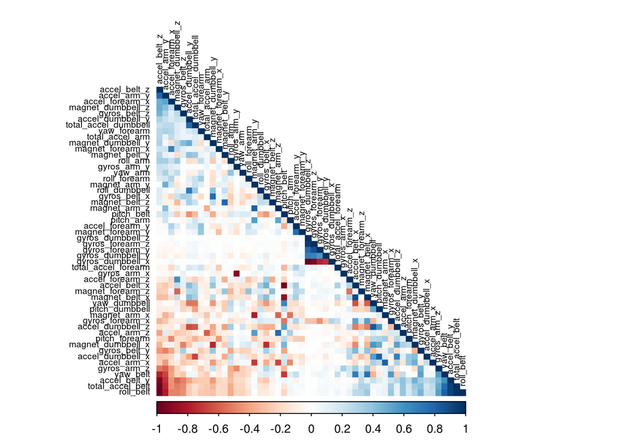

```r
corMat <- cor(smallTrain[,-53])
corrplot(corMat, order = 'FPC', method = 'color', type = 'lower', tl.cex = 0.6,
         tl.col = rgb(0,0,0))
```

Due to the number of columns, it is not easy to inspect the correlation plot however.

### Model Fitting: 1. Feature scaling + Multinomial Log-Linear Model

Our first attempt would be to fit a Multinomial Log-Linear Model. Before doing that, we preprocess the data by centering and scaling the training and validation sets:

```r
preprocessData <- preProcess(smallTrain[-53], method=c("center", "scale"))
smallTrain_scaled <- predict(preprocessData, smallTrain[-53])
smallValid_scaled <- predict(preprocessData, smallValid[,-53])
```

The first model we fit is Multinomial Log-Linear Model:

```r
library(nnet)
fit_multinom <- multinom(smallTrain$classe ~ ., data = smallTrain_scaled, maxit = 400)
```

The params converged after 241 iterations.

We can check the summary of the fit and the p-values of the coefficients with the below code but we do not show the results here:

```r
   summ_fit = summary(fit_multinom)
   z <- summ_fit$coefficients/summ_fit$standard.errors
   p <- (1 - pnorm(abs(z), 0, 1)) * 2
```

To observe the size of the coefficients, we can simply exponentiate them:

```r
exp(coef(fit_multinom))
```

After some initial inspection of the resulting model, we fit it to the training data and obtain a matrix of probabilities of how likely it would fit to each of the 5 classes of activity. We choose the class with the highest predicted probability to be the predicted label of that observation:

```r
pp <- fitted(fit_multinom)
trainPred <- predict(fit_multinom, newdata = smallTrain_scaled, "probs")
trainPred <- data.frame(cbind(trainPred, class_no = max.col(trainPred)))
```

We relabel the predicted labels from 1-5 to A-E using plyr::join. We do not use base::merge because this function would reorder the data while plyr::join does not. After some treatment, we can look at the prediction accuracy:

```r
library(plyr)
lookup <- data.frame(class_no = c(1,2,3,4,5), class = c('A','B','C','D','E'))
trainPred <- join(trainPred, lookup, by = 'class_no')
trainPred$class <- as.factor(trainPred$class)
head(trainPred)
```

```
##           A            B            C            D            E class_no
## 1 0.9985179 0.0011097304 1.518365e-04 7.641744e-05 0.0001441496        1
## 2 0.9970121 0.0017861204 4.422039e-04 1.898037e-04 0.0005697938        1
## 3 0.9979423 0.0013545554 2.442268e-04 1.584711e-04 0.0003004406        1
## 4 0.9965715 0.0020223878 3.706488e-04 2.231319e-04 0.0008123473        1
## 5 0.9981441 0.0011361378 1.853292e-04 1.312053e-04 0.0004032231        1
## 6 0.9990783 0.0006452978 8.443632e-05 6.289542e-05 0.0001290742        1
##   class
## 1     A
## 2     A
## 3     A
## 4     A
## 5     A
## 6     A
```

```r
table(trainPred$class, smallTrain$classe)
```

```
##
##        A    B    C    D    E
##   A 3334  332  209  144  117
##   B  125 1709  204   87  315
##   C  189  239 1670  251  152
##   D  149   90  157 1614  199
##   E   33  233  107  107 1687
```

```r
postResample(smallTrain$classe, trainPred$class)
```

```
##  Accuracy     Kappa
## 0.7443693 0.6757944
```

For the training set, the accuracy is 74.4%, which is not very high.

We then fit the trained multinom model to the scaled validation data:

```r
validPred <- predict(fit_multinom, newdata = smallValid_scaled, "probs")
validPred <- data.frame(cbind(validPred, class_no = max.col(validPred)))

validPred <- join(validPred, lookup, by = 'class_no')
validPred$class <- as.factor(validPred$class)

table(validPred$class, smallValid$classe)
```

```
##
##        A    B    C    D    E
##   A 1395  135   84   56   46
##   B   43  747   86   39  123
##   C  103  114  737  116   59
##   D   86   37   61  677   95
##   E   14   82   37   56  735
```

```r
postResample(smallValid$classe, validPred$class)
```

```
##  Accuracy     Kappa
## 0.7445775 0.6765143
```

#### Still, the Multinomial Log-Linear Model doesn’t yield satisfying result, with only 74.5% validation accuracy. We set off to try other algorithms.

### Model Fitting: 2. PCA + Random Forest

We then try the very popular model, Random Forest. Since the datasets have many features and Random Forest is computationally expensive, we first reduce data dimensionality using PCA.

We set the threshold to obtain the Principal Components which capture 99% variance. The same params are applied to both the training and validation datasets:

```r
preProc <- preProcess(smallTrain[, -53], method = "pca", thresh = .99)
preProc
```

```
## Created from 13453 samples and 52 variables
##
## Pre-processing:
##   - centered (52)
##   - ignored (0)
##   - principal component signal extraction (52)
##   - scaled (52)
##
## PCA needed 36 components to capture 99 percent of the variance
```

```r
trainPC <- predict(preProc, smallTrain[, -53])
validPC <- predict(preProc, smallValid[, -53])
```

We then train a Random Forest Model with the resulted Principal Components:

```r
fit_RF <- train(x = trainPC, y = smallTrain$classe, method = "rf",
                trControl = trainControl(method = "cv", number = 4), importance = TRUE)
```

```r
fit_RF
```

```
## Random Forest
##
## 13453 samples
##    36 predictors
##     5 classes: 'A', 'B', 'C', 'D', 'E'
##
## No pre-processing
## Resampling: Cross-Validated (4 fold)
## Summary of sample sizes: 10090, 10090, 10089, 10090
## Resampling results across tuning parameters:
##
##   mtry  Accuracy   Kappa
##    2    0.9740576  0.9671651
##   19    0.9687057  0.9603978
##   36    0.9581506  0.9470403
##
## Accuracy was used to select the optimal model using  the largest value.
## The final value used for the model was mtry = 2.
```

We use a dotchart to show the importance of each Principal Component to the model (higher = more important):

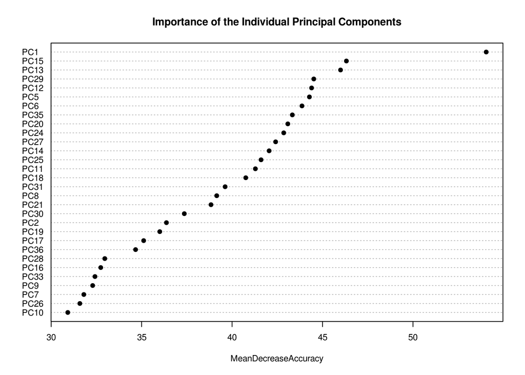

```r
varImpPlot(fit_RF$finalModel, sort = TRUE, type = 1, pch = 19, col = 1, cex = .7,
           main = "Importance of the Individual Principal Components")
```

Lastly, we apply the trained Random Forest Model to the validation set:

```r
validPredict_RF <- predict(fit_RF, newdata = validPC)
confMatrix <- confusionMatrix(smallValid$classe, validPredict_RF)
confMatrix
```

```
## Confusion Matrix and Statistics
##
##           Reference
## Prediction    A    B    C    D    E
##          A 1638    1    0    2    0
##          B   23 1086    4    0    2
##          C    1   17  977    8    2
##          D    1    4   49  886    4
##          E    0    7    3    5 1043
##
## Overall Statistics
##
##                Accuracy : 0.9769
##                  95% CI : (0.9727, 0.9806)
##     No Information Rate : 0.2886
##     P-Value [Acc > NIR] : < 2.2e-16
##
##                   Kappa : 0.9708
##  Mcnemar's Test P-Value : NA
##
## Statistics by Class:
##
##                      Class: A Class: B Class: C Class: D Class: E
## Sensitivity            0.9850   0.9740   0.9458   0.9834   0.9924
## Specificity            0.9993   0.9938   0.9941   0.9881   0.9968
## Pos Pred Value         0.9982   0.9740   0.9721   0.9386   0.9858
## Neg Pred Value         0.9939   0.9938   0.9882   0.9969   0.9983
## Prevalence             0.2886   0.1935   0.1792   0.1563   0.1824
## Detection Rate         0.2842   0.1884   0.1695   0.1537   0.1810
## Detection Prevalence   0.2847   0.1935   0.1744   0.1638   0.1836
## Balanced Accuracy      0.9921   0.9839   0.9699   0.9857   0.9946
```

#### Although the Random Forest Model is slow in computation, but it has achieved a highly statisfying result of 97.7%.